# Dacon_항공편지연예측_python_upload

https://dacon.io/competitions/official/236094/overview/description

#### '도착지','출발지','거리','항공사', 등으로 구성된 데이터를 활용하여 항공편의 지연여부를 예측하는 대회이다.

#### 원 데이터(train.csv)로 진행하여 대회 종류 후 제출한 결과는 아래와 같다.(2023-06-15)

#### 결과순위 : **1204팀** 중 57위 (닉네임:newhyh)

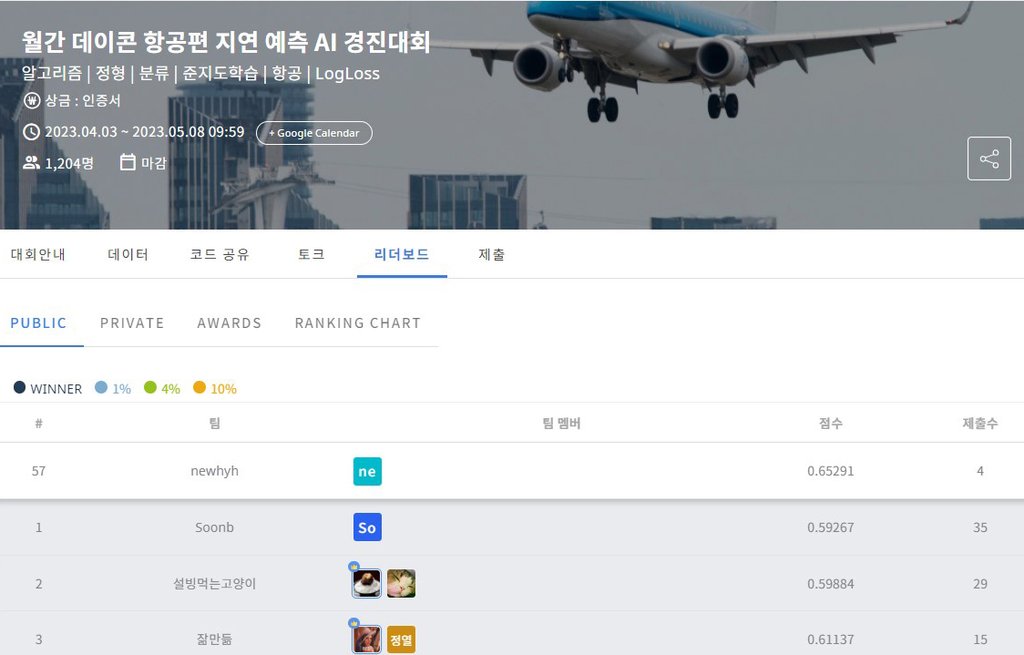

```python
from IPython.display import clear_output
from IPython.display import Image
Image('daconairline_2.jpg')
```

### 분석 Keypoint ======================================

#### 1. 학습에 사용 될 새로운 변수로 반응변수와 상관성이 높은 지연율 변수 생성

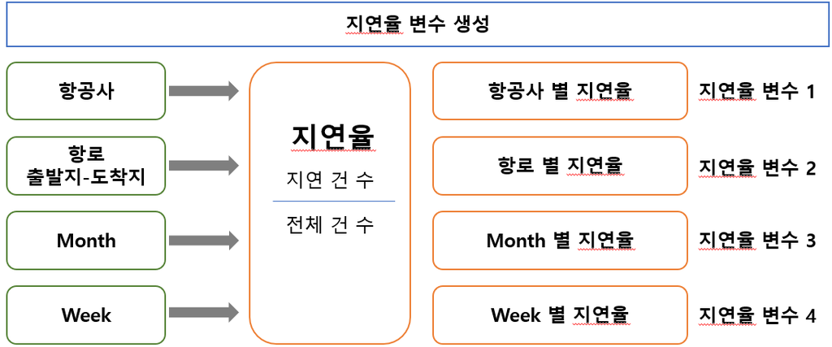

```python
Image('지연율.png')
```

#### 2. 명목형 변수가 많으므로 이에 유리한 CATBOOST를 적용.

#### [ 데이터 개요 ]

```python
import pandas as pd
import numpy as np
import janitor
```

```python
import warnings
warnings.filterwarnings(action='ignore')
```

```python
dat = pd.read_csv('./open/train.csv')
```

```python
dat = dat.clean_names()
```

### EDA =============================================

```python
dat.info()
```

```
<class 'pandas.core.frame.DataFrame'>
RangeIndex: 1000000 entries, 0 to 999999
Data columns (total 19 columns):
 #   Column                    Non-Null Count    Dtype
---  ------                    --------------    -----
 0   id                        1000000 non-null  object
 1   month                     1000000 non-null  int64
 2   day_of_month              1000000 non-null  int64
 3   estimated_departure_time  890981 non-null   float64
 4   estimated_arrival_time    890960 non-null   float64
 5   cancelled                 1000000 non-null  int64
 6   diverted                  1000000 non-null  int64
 7   origin_airport            1000000 non-null  object
 8   origin_airport_id         1000000 non-null  int64
 9   origin_state              890985 non-null   object
 10  destination_airport       1000000 non-null  object
 11  destination_airport_id    1000000 non-null  int64
 12  destination_state         890921 non-null   object
 13  distance                  1000000 non-null  float64
 14  airline                   891080 non-null   object
 15  carrier_code_iata_        891010 non-null   object
 16  carrier_id_dot_           891003 non-null   float64
 17  tail_number               1000000 non-null  object
 18  delay                     255001 non-null   object
dtypes: float64(4), int64(6), object(9)
memory usage: 145.0+ MB
```

```python
dat.iloc[:5,1:10]
```

|  | month | day_of_month | estimated_departure_time | estimated_arrival_time | cancelled | diverted | origin_airport | origin_airport_id | origin_state |
| --- | --- | --- | --- | --- | --- | --- | --- | --- | --- |
| 0 | 4 | 15 | NaN | NaN | 0 | 0 | OKC | 13851 | Oklahoma |
| 1 | 8 | 15 | 740.0 | 1024.0 | 0 | 0 | ORD | 13930 | Illinois |
| 2 | 9 | 6 | 1610.0 | 1805.0 | 0 | 0 | CLT | 11057 | North Carolina |
| 3 | 7 | 10 | 905.0 | 1735.0 | 0 | 0 | LAX | 12892 | California |
| 4 | 1 | 11 | 900.0 | 1019.0 | 0 | 0 | SFO | 14771 | California |

```python
dat.iloc[:5,10:]
```

|  | destination_airport | destination_airport_id | destination_state | distance | airline | carrier_code_iata_ | carrier_id_dot_ | tail_number | delay |
| --- | --- | --- | --- | --- | --- | --- | --- | --- | --- |
| 0 | HOU | 12191 | Texas | 419.0 | Southwest Airlines Co. | WN | 19393.0 | N7858A | NaN |
| 1 | SLC | 14869 | Utah | 1250.0 | SkyWest Airlines Inc. | UA | 20304.0 | N125SY | NaN |
| 2 | LGA | 12953 | New York | 544.0 | American Airlines Inc. | AA | 19805.0 | N103US | NaN |
| 3 | EWR | 11618 | New Jersey | 2454.0 | United Air Lines Inc. | UA | NaN | N595UA | NaN |
| 4 | ACV | 10157 | California | 250.0 | SkyWest Airlines Inc. | UA | 20304.0 | N161SY | NaN |

```python
dat.select_dtypes('number').drop(['destination_airport_id','origin_airport_id','carrier_id_dot_'],axis=1).describe()
```

|  | month | day_of_month | estimated_departure_time | estimated_arrival_time | cancelled | diverted | distance |
| --- | --- | --- | --- | --- | --- | --- | --- |
| count | 1000000.000000 | 1000000.000000 | 890981.000000 | 890960.000000 | 1000000.0 | 1000000.0 | 1000000.000000 |
| mean | 6.945156 | 15.764842 | 1341.153019 | 1493.295934 | 0.0 | 0.0 | 784.078499 |
| std | 3.462506 | 8.763515 | 489.814011 | 520.803494 | 0.0 | 0.0 | 590.790469 |
| min | 1.000000 | 1.000000 | 1.000000 | 1.000000 | 0.0 | 0.0 | 16.000000 |
| 25% | 4.000000 | 8.000000 | 925.000000 | 1105.000000 | 0.0 | 0.0 | 350.000000 |
| 50% | 7.000000 | 16.000000 | 1332.000000 | 1524.000000 | 0.0 | 0.0 | 623.000000 |
| 75% | 10.000000 | 23.000000 | 1742.000000 | 1924.000000 | 0.0 | 0.0 | 1020.000000 |
| max | 12.000000 | 31.000000 | 2359.000000 | 2400.000000 | 0.0 | 0.0 | 5095.000000 |

```python
print(dat.cancelled.unique())
print(dat.diverted.unique())
```

```
[0]
[0]
```

'cancelled','diverted'값이 모두 0이므로 삭제

```python
dat = dat.drop(['cancelled','diverted'],axis=1)
```

```python
import matplotlib.pyplot as plt
import seaborn as sns
```

Mnth: 해당 항공편의 출발 월, Day_f_Mnth: Mnth에 해당하는 월의 날짜

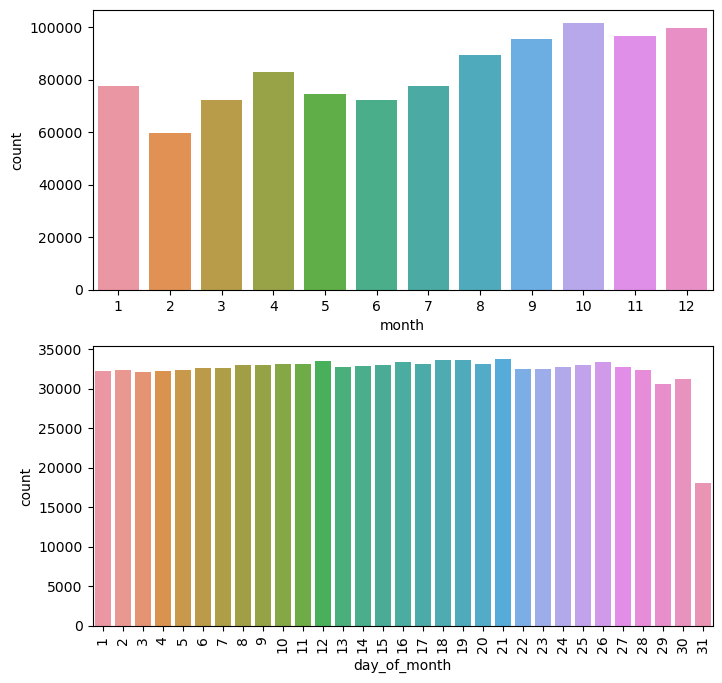

```python
fig = plt.figure(figsize=(8,8))
plt.subplots_adjust( hspace=0.2)

ax1 = fig.add_subplot(2,1,1)
ax2 = fig.add_subplot(2,1,2)
sns.countplot(dat['month'], ax=ax1)
sns.countplot(dat['day_of_month'], ax=ax2)
plt.xticks(rotation=90)
plt.show()
```

Estimated_Departure_Time: 전산 시스템을 바탕으로 측정된 비행기의 출발 시간  
Estimated_Arrival_Time: 전산 시스템을 바탕으로 측정된 비행기의 도착 시간  
Distance: 출발 공항과 도착 공항 사이의 거리 (mile 단위)

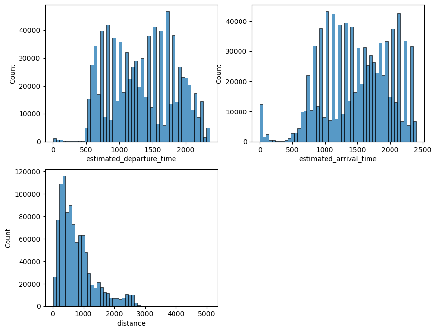

```python
fig = plt.figure(figsize=(10,8))
ax1 = fig.add_subplot(2,2,1)
ax2 = fig.add_subplot(2,2,2)
ax3 = fig.add_subplot(2,2,3)

sns.histplot(x=dat['estimated_departure_time'], bins=50, ax=ax1)
sns.histplot(x=dat['estimated_arrival_time'], bins=50, ax=ax2)
sns.histplot(x=dat['distance'], bins=50, ax=ax3)
```

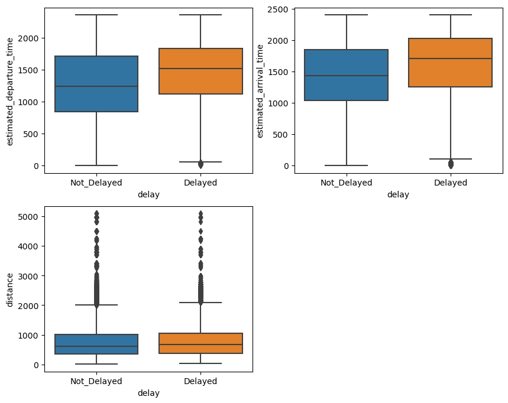

```python
fig = plt.figure(figsize=(10,8))
ax1 = fig.add_subplot(2,2,1)
ax2 = fig.add_subplot(2,2,2)
ax3 = fig.add_subplot(2,2,3)

sns.boxplot(y=dat['estimated_departure_time'],x=dat['delay'], ax=ax1)
sns.boxplot(y=dat['estimated_arrival_time'],x=dat['delay'], ax=ax2)
sns.boxplot(y=dat['distance'],x=dat['delay'], ax=ax3)
```

### 결측 처리 ==========================================

```python
dat.isnull().sum()
```

```
id                               0
month                            0
day_of_month                     0
estimated_departure_time    109019
estimated_arrival_time      109040
origin_airport                   0
origin_airport_id                0
origin_state                109015
destination_airport              0
destination_airport_id           0
destination_state           109079
distance                         0
airline                     108920
carrier_code_iata_          108990
carrier_id_dot_             108997
tail_number                      0
delay                       744999
dtype: int64
```

#### 반응변수 결측 처리

```python
# 반응변수 NA인 데이터가 744999개이다. 삭제 처리
dat = dat.dropna(subset='delay')
dat.delay.isnull().sum()
```

```
0
```

명목형 수치형 분리

```python
dat_ca = dat.select_dtypes('object')
dat_num = dat.select_dtypes('number')
```

#### 설명변수 결측 처리 : 명목형 데이터

```python
dc_name = dat_ca.drop(['id'], axis = 1).columns.tolist()
```

```python
# "" 빈데이터 확인
for i in range(len(dc_name)) :
    cate = dat_ca[dc_name[i]].unique().tolist()
    if "" in cate :
        print(dc_name[i])
    elif " " in cate :
        print(dc_name[i])
```

명목형 데이터 결측치를 삭제하지 않고 "unknown"으로 대체

```python
dat_ca = dat_ca.fillna("unknown")
```

```python
for i in range(len(dc_name)) :
    cate = dat_ca[dc_name[i]].unique().tolist()
    if "unknown" in cate :
        print(dc_name[i])
```

```
origin_state
destination_state
airline
carrier_code_iata_
```

```python
dat_ca.isnull().sum()
```

```
id                     0
origin_airport         0
origin_state           0
destination_airport    0
destination_state      0
airline                0
carrier_code_iata_     0
tail_number            0
delay                  0
dtype: int64
```

#### 설명변수 결측 처리 : 수치형 데이터

```python
from sklearn.experimental import enable_iterative_imputer
from sklearn.impute import IterativeImputer
from sklearn.linear_model import LinearRegression
```

```python
lr = LinearRegression()
imputer = IterativeImputer(estimator = lr, max_iter = 10)
impute_value = imputer.fit_transform(dat_num)
dat_num = pd.DataFrame(impute_value, columns=dat_num.columns)
```

```python
dat_num.isnull().sum()
```

```
month                       0
day_of_month                0
estimated_departure_time    0
estimated_arrival_time      0
origin_airport_id           0
destination_airport_id      0
distance                    0
carrier_id_dot_             0
dtype: int64
```

합치기

```python
dat1 = pd.concat([dat_num, dat_ca], axis = 1)
```

### FEATURE ENGINEERING & 전처리 =====================

#### A.지연율 등의 새 변수 생성

[ 출발지 id + 도착지 id ]

1. '항공사 출발지id','항공사 도착지id' 두 개의 변수를 합쳐서 고유한 1개의 변수로 만든다.  
   [ 변수 별 '지연율' 생성 ]  
   각 주요 변수별로 지연율이 결국 지연 여부에 영향을 미친다는 것을 상식적으로 추론할 수 있다.
2. orgdet_retio_delay : '출발지id+도착지id'별 지연율( 지연건수/전체건수)
3. airline_retio_delay : '항공사'별 지연율( 지연건수/전체건수)
4. month_retio_delay : '월' 별 지연율( 지연건수/전체건수)
5. week_retio_delay : '요일'별 지연율( 지연건수/전체건수) : 날짜 데이터 => 요일 데이터 변환  
   [ 거리 변수 ]
6. distance_orgdet : '출발지id+도착지id' 별 거리
7. dist_rank : '출발지id+도착지id' 거리에 따른 고유 번호

#### B.변수 선택

독립변수 : 새 변수 7개 + 기존 변수 6  
(week,month,airline,distance,estimated_departure_time,estimated_arrival_time)

#### C.1차 머신러닝 맟 차원 축소

1차 머신러닝에서 varImp(cat0)를 통해 주요 변수를 확인한다.  
확인 결과 week,month 변수가 주요변수가 아니다. 제외한다.  
'항공사'는 자동 더미인코딩되어 각 항공사가 개별 변수가 된다.  
주요 변수에 포함되지 않은 항공사가 많다. 하나로 통합한다.  
기존 항공사 인코딩 변수 29개 ==> 16개 축소

#### D.데이터 축소

출발지_도착지 고유id라 할 수 있는 dist_rank별로 데이터를 30%로 줄인다.

```python
import pickle
```

```python
#  불러오기
with open("dat1.pickle","rb") as fi:
    dat_load = pickle.load(fi) # df.pickle 읽기
```

```python
dat_load.info()
```

```
<class 'pandas.core.frame.DataFrame'>
RangeIndex: 79448 entries, 0 to 79447
Data columns (total 11 columns):
 #   Column                    Non-Null Count  Dtype
---  ------                    --------------  -----
 0   dist_rank                 79448 non-null  float64
 1   distance_orgdet           79448 non-null  float64
 2   week_retio_delay          79448 non-null  float64
 3   month_retio_delay         79448 non-null  float64
 4   airline_retio_delay       79448 non-null  float64
 5   orgdet_retio_delay        79448 non-null  float64
 6   distance                  79448 non-null  float64
 7   estimated_departure_time  79448 non-null  float64
 8   estimated_arrival_time    79448 non-null  float64
 9   delay                     79448 non-null  object
 10  airline                   79448 non-null  object
dtypes: float64(9), object(2)
memory usage: 6.7+ MB
```

```python
dat_load.isna().sum()
```

```
dist_rank                   0
distance_orgdet             0
week_retio_delay            0
month_retio_delay           0
airline_retio_delay         0
orgdet_retio_delay          0
distance                    0
estimated_departure_time    0
estimated_arrival_time      0
delay                       0
airline                     0
dtype: int64
```

```python
dat1 = dat_load.copy()
dat1.head()
```

|  | dist_rank | distance_orgdet | week_retio_delay | month_retio_delay | airline_retio_delay | orgdet_retio_delay | distance | estimated_departure_time | estimated_arrival_time | delay | airline |
| --- | --- | --- | --- | --- | --- | --- | --- | --- | --- | --- | --- |
| 0 | 1.0 | 16.0 | 0.173475 | 0.168419 | 0.175563 | 0.0 | 16.0 | 1540.0 | 1602.000000 | Not_Delayed | etc |
| 1 | 2.0 | 16.0 | 0.177055 | 0.208435 | 0.126623 | 0.0 | 16.0 | 955.0 | 1017.000000 | Not_Delayed | Empire.Airlines.Inc. |
| 2 | 3.0 | 27.0 | 0.173475 | 0.208435 | 0.126623 | 0.0 | 27.0 | 718.0 | 736.000000 | Not_Delayed | Empire.Airlines.Inc. |
| 3 | 4.0 | 31.0 | 0.188088 | 0.222222 | 0.155701 | 0.1 | 31.0 | 1500.0 | 1597.988617 | Not_Delayed | etc |
| 4 | 4.0 | 31.0 | 0.188088 | 0.206872 | 0.155701 | 0.1 | 31.0 | 1504.0 | 1526.000000 | Not_Delayed | etc |

#### 상관관계 확인 및 2차 차원축소

```python
import matplotlib.pyplot as plt
import seaborn as sns
```

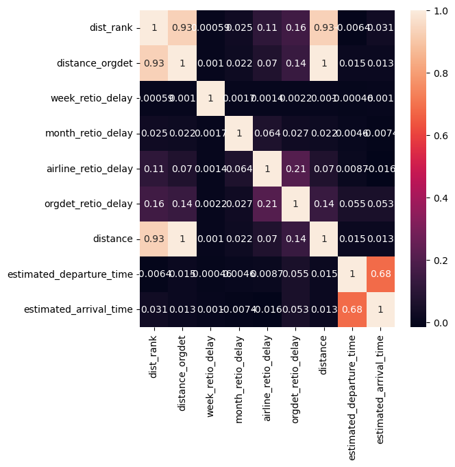

```python
plt.figure(figsize=(6,6))
corr = dat1.select_dtypes('number').corr()
sns.heatmap(corr, annot = True)
plt.show();
```

distance_orgdet,dist_rank,distance 간의 상관계수가 0.9이상이다.  
이 중 distance_orgdet만 남기고 삭제한다.

```python
dat2 = dat1.drop(['dist_rank','distance'],axis=1)
```

```python
dat2.info()
```

```
<class 'pandas.core.frame.DataFrame'>
RangeIndex: 79448 entries, 0 to 79447
Data columns (total 9 columns):
 #   Column                    Non-Null Count  Dtype
---  ------                    --------------  -----
 0   distance_orgdet           79448 non-null  float64
 1   week_retio_delay          79448 non-null  float64
 2   month_retio_delay         79448 non-null  float64
 3   airline_retio_delay       79448 non-null  float64
 4   orgdet_retio_delay        79448 non-null  float64
 5   estimated_departure_time  79448 non-null  float64
 6   estimated_arrival_time    79448 non-null  float64
 7   delay                     79448 non-null  object
 8   airline                   79448 non-null  object
dtypes: float64(7), object(2)
memory usage: 5.5+ MB
```

```python
from sklearn.model_selection import train_test_split
```

```python
y_train = dat2.delay
X_train = dat2.drop(['delay'], axis = 1)
```

#### 결과변수 클래스 불균형 확인

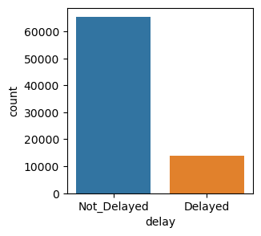

```python
plt.figure(figsize=(3,3))
sns.countplot(y_train)
plt.show()
```

#### 클래스 불균형 처리

```python
from imblearn.over_sampling import RandomOverSampler
```

```python
oversample = RandomOverSampler(sampling_strategy='minority')
X_train_over, y_train_over = oversample.fit_resample(X_train,y_train)
```

```python
from collections import Counter
print(Counter(y_train_over))
```

```
Counter({'Not_Delayed': 65492, 'Delayed': 65492})
```

```python
X_train_over.info()
```

```
<class 'pandas.core.frame.DataFrame'>
RangeIndex: 130984 entries, 0 to 130983
Data columns (total 8 columns):
 #   Column                    Non-Null Count   Dtype
---  ------                    --------------   -----
 0   distance_orgdet           130984 non-null  float64
 1   week_retio_delay          130984 non-null  float64
 2   month_retio_delay         130984 non-null  float64
 3   airline_retio_delay       130984 non-null  float64
 4   orgdet_retio_delay        130984 non-null  float64
 5   estimated_departure_time  130984 non-null  float64
 6   estimated_arrival_time    130984 non-null  float64
 7   airline                   130984 non-null  object
dtypes: float64(7), object(1)
memory usage: 8.0+ MB
```

연속형 : 정규화

```python
num_columns = X_train_over.select_dtypes('number')
cat_columns = X_train_over.select_dtypes('object')
```

```python
from sklearn.preprocessing import MinMaxScaler
```

```python
mxscaler = MinMaxScaler()
num_col_n = mxscaler.fit_transform(num_columns)
```

```python
num_columns = pd.DataFrame(num_col_n, columns = num_columns.columns)
```

```python
 X_train_over = pd.concat([num_columns,cat_columns], axis = 1)
```

### CATBOOST 머신러닝 ================================

```python
from sklearn.model_selection import GridSearchCV, KFold
from sklearn.metrics import confusion_matrix, classification_report, accuracy_score, balanced_accuracy_score, plot_roc_curve, roc_auc_score, roc_curve
from sklearn.model_selection import cross_val_score
```

```python
param_cat = {'depth': [4, 6, 8],
              'learning_rate': [0.01,0.05, 0.1, 0.2],
              'iterations': [100, 200, 300]}
```

```python
cv = KFold(n_splits = 5, shuffle = True, random_state = 0)
```

```python
from catboost import CatBoostClassifier
```

대용량 처리를 위해 GPU 사용

```python
cat_features = ['airline']
cat = CatBoostClassifier(cat_features=cat_features,task_type='GPU')
```

```python
cat_search = GridSearchCV (estimator = cat,
              param_grid = param_cat,
              cv = cv,
              scoring = 'balanced_accuracy')
```

```python
from pytictoc import TicToc
```

```python
time = TicToc()
time.tic()
cat_search.fit(X_train_over, y_train_over )
time.toc()
```

#### 예측

```python
with open("test.pickle","rb") as fi:
    test = pickle.load(fi) # df.pickle 읽기
X_test = test.drop(['dist_rank','distance'],axis=1)
X_test.info()
```

```
<class 'pandas.core.frame.DataFrame'>
RangeIndex: 1000000 entries, 0 to 999999
Data columns (total 8 columns):
 #   Column                    Non-Null Count    Dtype
---  ------                    --------------    -----
 0   distance_orgdet           1000000 non-null  float64
 1   week_retio_delay          1000000 non-null  float64
 2   month_retio_delay         1000000 non-null  float64
 3   airline_retio_delay       1000000 non-null  float64
 4   orgdet_retio_delay        1000000 non-null  float64
 5   airline                   1000000 non-null  object
 6   estimated_departure_time  1000000 non-null  float64
 7   estimated_arrival_time    1000000 non-null  float64
dtypes: float64(7), object(1)
memory usage: 61.0+ MB
```

```python
pred = cat_search.predict(X_test)
```